[figure not shown]

# Fundamentals of Artificial Intelligence and Machine Learning

## Project #1

# Context

Cardio Good Fitness is seeking to identify differneces between the customers of three of their products. They would like a customer profile for each product with insights and recommendations that will improve marketing efforts

# Objective

- Identify the customer profile for each product
- Identify recommendations for marketing each product

# Key Questions

- What is the age range for each product?
- What is the income range from each product?
- Which product should be marketed to with gender?
- Which prodcut should be marketed to customers who consider themselve very fit?
- Does Education or Income factor into the which product is purchased?

# Executive Summary

Cardio Good Fitness is looking to expand it marketting efforts for their three different treadmill products. To effectively utilize the limited marketing budget customer profiles are needed to accomplish the company goals

To perform this analysis a dataset of 180 previous sales was analyed. In this data set the following was observed:

- The minimum age of customers is 18. The maximum is 50. The average age is 28.7
- The number of male customers is 104 and the number of female customers is 76
- The number of married customers is 107 and the number of single cusomers is 73.
- The overall average income of all customers is $53,719
- The average number of years of education is 15.5 but education only showed minimal impact on product with the highest education correlating to income and higher income customers did tend to purchase the TM798

## Actionable Insights and Recommendations

### TM195

Marketing of this model to married customers during primetime TV viewing windows and to singles during dating and reality shows is suggested. Adds should show average fitness level people using the product to get and stay fit. The ads should project value at a good price

### TM498

Marketing of this model in popular womens magazines and during the nightly news on TV is suggested. Adds should show average fitness level people using the product to get and stay fit. Ephasis should be ginven to longer runs. Ads should project balance between value and benefits

### TM798

This is the top end model. The TM798 has the least common model in the dataser.This model is most popular with single men who are on average 30 years old. Women do buy this model as well but their average age is 24. The typical profile of this product;s customer is:

Marketing of this model in popular mens and womens fitness magazines and during sporting events on TV and radio is suggested, Adds should show well fit athletes and emphasize that it is for people who believe they are fit and want to stay that way. These adds should project status and luxury

### Future Potential Analysis

The data didn't contain any dated inforation about when the product was purchased. Collecting this data could help it identifing the time of year that advertising would be most effective

The data didn't contain and information on the cost of the product. Collecting this data would allow for analysis of price and how it correlates to income

# Initialization

- Upgrading matplot lib
- Loading required libraries
- Setting up file system
- Define path and fileName
- Open the dataset, set to df

```python
# Ensure that the latest version of matplolib is being used
!pip install --upgrade matplotlib
```

```python
import matplotlib
print(matplotlib. __version__)
```

```
3.5.1
```

```python
# import the necssart libraries to help with data manipulation

import numpy as np
import pandas as pd

# Libraries to help with data visualization
import matplotlib.pyplot as plt
import seaborn as sns
%matplotlib inline

# Connect to Google Drive and define the location and filename of the raw dataset
from google.colab import drive
drive.mount('/content/drive')
path="/content/drive/MyDrive/Colab Notebooks/01 - Fundamentals of AIML/Project/"
fileName = "CardioGoodFitness.csv"
```

```python
# Open the designated file and load the dataFrame into the variable df
df = pd.read_csv(path+fileName)
```

## Helper Functions

These functions must be loaded before using them later in this notbook

### histogram_boxplot Function

This function was copied with permission from the Uber Case Study notebook. This function will output a boxplot and a histogram of simultaneously

```python
def histogram_boxplot(data, feature, figsize=(12, 7), kde=False, bins=None):
    """
    Boxplot and histogram combined

    data: dataframe
    feature: dataframe column
    figsize: size of figure (default (12,7))
    kde: whether to show the density curve (default False)
    bins: number of bins for histogram (default None)
    """
    f2, (ax_box2, ax_hist2) = plt.subplots(
        nrows=2,  # Number of rows of the subplot grid= 2
        sharex=True,  # x-axis will be shared among all subplots
        gridspec_kw={"height_ratios": (0.25, 0.75)},
        figsize=figsize)  # creating the 2 subplots

    sns.boxplot(data=data, x=feature, ax=ax_box2, showmeans=True, color="violet")  # boxplot will be created and a star will indicate the mean value of the column

    if bins:
      sns.histplot(data=data, x=feature, kde=kde, ax=ax_hist2, bins=bins, palette="winter")
    else:
      sns.histplot(data=data, x=feature, kde=kde, ax=ax_hist2)  # For histogram

    ax_hist2.axvline(data[feature].mean(), color="green", linestyle="--")  # Add mean to the histogram

    ax_hist2.axvline(data[feature].median(), color="black", linestyle="-")  # Add median to the histogram
```

### labeled_barplot function

This functon was copied with permission from the Uber Case Study notebook. This fuction creates a standsard barplot but adds the percentage to the top of **each** of the bars

```python
def labeled_barplot(data, x, y=None, hue=None, n=None):
    """
    Barplot with percentage at the top

    data: dataframe
    x: dataframe categorical variable
    y: dataframe numerical variable,
      if y is None, use countplot, otherwis use barplot
    hue: dataframe column for addition category
    n: displays the top n category levels (default is None, i.e., display all levels)
    """

    count = data[x].nunique()
    if hue is None:
        m = 1
    else:
        m = data[hue].nunique()

    if n is None:
        plt.figure(figsize=(count * m + 3, 7))
    else:
        plt.figure(figsize=((n + 1) * m + 3, 7))

    plt.xticks(rotation=90, fontsize=15)
    if y:
      ax = sns.barplot(
          data=data,
          x=x,
          y=y,
          hue=hue,
          order=data.sort_values(y, ascending=False).head(n)[x],
          palette ='Pastel2'
          )
    else:
      ax = sns.countplot(
          data=data,
          x=x,
          hue=hue,
          order=data[x].value_counts().sort_values(ascending=False).index[:n],
          palette="Paired"
          )

    for c in ax.containers:
            ax.bar_label(c, fmt='%.2f')
```

# Data Overview

```python
df.head()
```

|  | Product | Age | Gender | Education | MaritalStatus | Usage | Fitness | Income | Miles |
| --- | --- | --- | --- | --- | --- | --- | --- | --- | --- |
| 0 | TM195 | 18 | Male | 14 | Single | 3 | 4 | 29562 | 112 |
| 1 | TM195 | 19 | Male | 15 | Single | 2 | 3 | 31836 | 75 |
| 2 | TM195 | 19 | Female | 14 | Partnered | 4 | 3 | 30699 | 66 |
| 3 | TM195 | 19 | Male | 12 | Single | 3 | 3 | 32973 | 85 |
| 4 | TM195 | 20 | Male | 13 | Partnered | 4 | 2 | 35247 | 47 |

```python
df.tail()
```

|  | Product | Age | Gender | Education | MaritalStatus | Usage | Fitness | Income | Miles |
| --- | --- | --- | --- | --- | --- | --- | --- | --- | --- |
| 175 | TM798 | 40 | Male | 21 | Single | 6 | 5 | 83416 | 200 |
| 176 | TM798 | 42 | Male | 18 | Single | 5 | 4 | 89641 | 200 |
| 177 | TM798 | 45 | Male | 16 | Single | 5 | 5 | 90886 | 160 |
| 178 | TM798 | 47 | Male | 18 | Partnered | 4 | 5 | 104581 | 120 |
| 179 | TM798 | 48 | Male | 18 | Partnered | 4 | 5 | 95508 | 180 |

```python
df.shape
```

```
(180, 9)
```

- There are 180 rows of data in 9 coluns

```python
df.info()
```

```
<class 'pandas.core.frame.DataFrame'>
RangeIndex: 180 entries, 0 to 179
Data columns (total 9 columns):
 #   Column         Non-Null Count  Dtype
---  ------         --------------  -----
 0   Product        180 non-null    object
 1   Age            180 non-null    int64
 2   Gender         180 non-null    object
 3   Education      180 non-null    int64
 4   MaritalStatus  180 non-null    object
 5   Usage          180 non-null    int64
 6   Fitness        180 non-null    int64
 7   Income         180 non-null    int64
 8   Miles          180 non-null    int64
dtypes: int64(6), object(3)
memory usage: 12.8+ KB
```

- all of the columns have 180 values telling us there is no missing data in the dataset
- The Product, Gender, and Marital Status are object type, the remaining are numerical (whole numbers)
- The object type are categorical

## Statistical Summary of Raw Dataset

```python
df.describe().T
```

|  | count | mean | std | min | 25% | 50% | 75% | max |
| --- | --- | --- | --- | --- | --- | --- | --- | --- |
| Age | 180.0 | 28.788889 | 6.943498 | 18.0 | 24.00 | 26.0 | 33.00 | 50.0 |
| Education | 180.0 | 15.572222 | 1.617055 | 12.0 | 14.00 | 16.0 | 16.00 | 21.0 |
| Usage | 180.0 | 3.455556 | 1.084797 | 2.0 | 3.00 | 3.0 | 4.00 | 7.0 |
| Fitness | 180.0 | 3.311111 | 0.958869 | 1.0 | 3.00 | 3.0 | 4.00 | 5.0 |
| Income | 180.0 | 53719.577778 | 16506.684226 | 29562.0 | 44058.75 | 50596.5 | 58668.00 | 104581.0 |
| Miles | 180.0 | 103.194444 | 51.863605 | 21.0 | 66.00 | 94.0 | 114.75 | 360.0 |

- Age
  - The minimum age is 18
  - The maximum age is 50
  - The average age is 28.7
- Income
  - The minumm income is 29,562
  - The maximum income is 104,581
  - The average income is 53,719
- Education
  - The minimum years of eduction is 12 (High School Graduate)
  - The maximum years of education is 21 (Doctrate degree)
  - The average years of education is 15.57 (Associates degree)
- Usage
  - The minimim planned usage is 2 time per week
  - The maximum planned usage is 7 tines per week
  - The average planned usage is 3.45 times per week
- Fitness
  - The minimum self reported fitness level is 1 (very unfit)
  - The maximum self reported fitenss level is 5 (very fit)
  - The average self reported fitness level is 3.3
- Miles
  - The minimum planned miles to run is 21
  - The maximum planned miles to run is 360
  - The average planned miles to run is 103
- There is a large difference between the 3rd quartile and the maximum value for the age, income and miles indicating that there may be outliers to the right in these variables

## Categorical column review

```python
df.nunique(dropna=False)
```

```
Product           3
Age              32
Gender            2
Education         8
MaritalStatus     2
Usage             6
Fitness           5
Income           62
Miles            37
dtype: int64
```

```python
df['Product'] = df['Product'].astype('category')
```

```python
df['Gender'] = df['Gender'].astype('category')
```

```python
df['MaritalStatus'] = df['MaritalStatus'].astype('category')
```

```python
df['Product'].unique()
```

```
['TM195', 'TM498', 'TM798']
Categories (3, object): ['TM195', 'TM498', 'TM798']
```

```python
df['Gender'].unique()
```

```
['Male', 'Female']
Categories (2, object): ['Female', 'Male']
```

```python
df['MaritalStatus'].unique()
```

```
['Single', 'Partnered']
Categories (2, object): ['Partnered', 'Single']
```

### Product Distibution

```python
df['Product'].value_counts()
```

```
TM195    80
TM498    60
TM798    40
Name: Product, dtype: int64
```

```python
df['Product'].value_counts(normalize=True)
```

```
TM195    0.444444
TM498    0.333333
TM798    0.222222
Name: Product, dtype: float64
```

- 80 customers (44.4%) purchased the TM195
- 60 customers (33.3%) purchased the TM498
- 40 customers (22.2%) purchased the TM798

### Gender Distribution

```python
df['Gender'].value_counts()
```

```
Male      104
Female     76
Name: Gender, dtype: int64
```

```python
df['Gender'].value_counts(normalize=True)
```

```
Male      0.577778
Female    0.422222
Name: Gender, dtype: float64
```

- 104 customers (57.7%) are male
- 76 customers (42.2%) are female

### Marital Status Distribution

```python
df['MaritalStatus'].value_counts()
```

```
Partnered    107
Single        73
Name: MaritalStatus, dtype: int64
```

```python
df['MaritalStatus'].value_counts(normalize=True)
```

```
Partnered    0.594444
Single       0.405556
Name: MaritalStatus, dtype: float64
```

- 107 customers (59.4%) have a partner
- 73 customers (40.5%) are single

## Fixing the data

- Missing Data Treatment
- Outlier Detection & Treatment

### Missing Data Treatment

```python
df.isna().sum()
```

```
Product          0
Age              0
Gender           0
Education        0
MaritalStatus    0
Usage            0
Fitness          0
Income           0
Miles            0
dtype: int64
```

There is no missing data in this dataset so no mitigation is necessary

### Outlier Detection & Treatment

While many of the rows have outlier data none felt like they were mistakes or compeltely out of the relm of possiblity so no outlier removal was done

# Univariate Analysis

## Exploratory Data Analysis

### Numerical columns

Using a combination of Historgram and boxplot of each numerical column to make general observations of the data

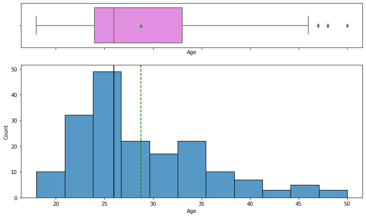

```python
# Age
histogram_boxplot(df, 'Age')
```

- The larget group of users is between 24 and 27
- The smallest group of users is between 41 and 44
- There are outliers on the right for age

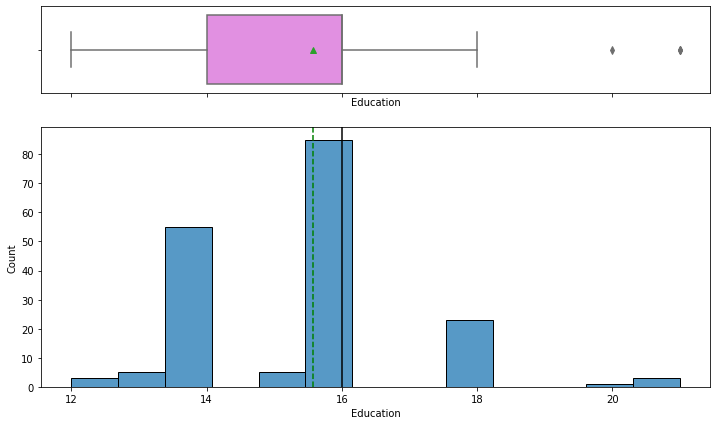

```python
# Education
histogram_boxplot(df, 'Education')
```

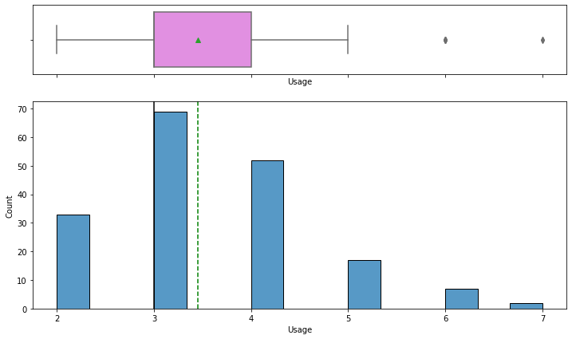

```python
# Usage Estimates Per Week
histogram_boxplot(df, 'Usage')
```

- The largest bin of estimated usage is 3 days
- The smallest bin of estimated usage is 7 days
- There are outliers on the right

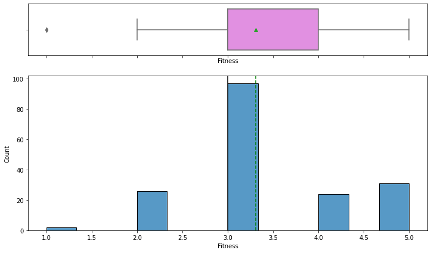

```python
# Fitness Level (Self Reported)
histogram_boxplot(df, 'Fitness')
```

- The largest bin of self reported fitness level is 3
- The lowset bin of self reported fitness level is 1
- There are outliers to the left

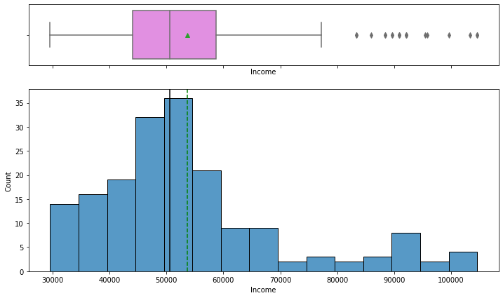

```python
# Income
histogram_boxplot(df, 'Income')
```

- The largest bin of income is 49,000 to 55,000
- The smallest bin of income is tied between 69,000 to 75,000, 79,000 to 85,000 and 95,000 to 99,000
- There are many outliers on the right
- There are extreme outliers on the right

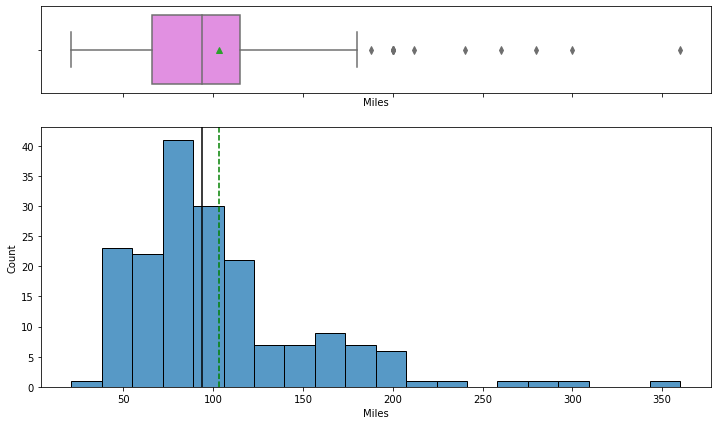

```python
# Miles planned
histogram_boxplot(df, 'Miles')
```

- The largest bin of estimated miles run is 75 to 80 The smallest bin of estimated miles (not including empty bins) is tied beween 25 - 40, 210 to 225, 225 to 240, 260 to 275, 275 to 290, 290 to 305 and 345 to 360
- The miles is right-skewed with several outloiwers on the right

### Categorical Columns

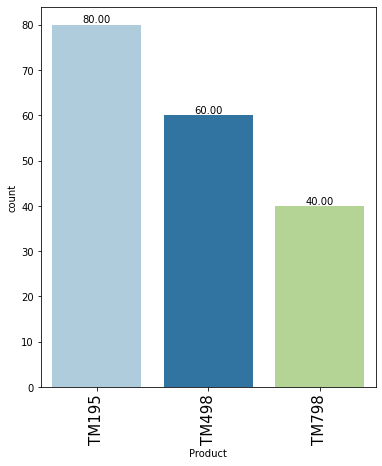

```python
labeled_barplot(df, 'Product')
```

- TM195 is the most common
- TM498 is the second most common
- TM798 is the least common

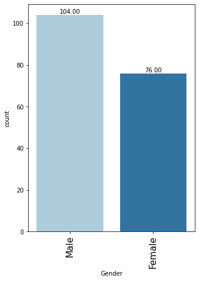

```python
labeled_barplot(df, 'Gender')
```

- There are more males in the dataset than females

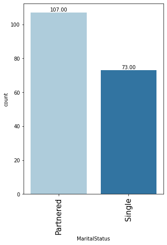

```python
labeled_barplot(df, 'MaritalStatus')
```

- There are more partneted couples than singles

# Bivariate Analysis

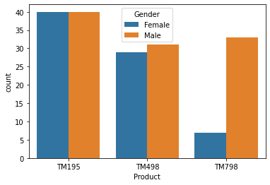

```python
# Show a graph that has the distribution of product purchased by gender

sns.countplot(data=df, x='Product', hue='Gender');
```

- An equal number of men and women purchase the TM195
- More men purchase the TM498 than women by a small margin
- Men purchase the TM798 far more than women do

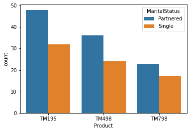

```python
# Show a graph that has the distribution of product purchased by Marital Status

sns.countplot(data=df, x='Product', hue='MaritalStatus');
```

- Patnered people purchase more of all three prodcuts

## Correlation of data

Identifying what numeric fields may have some relationship to each other to prompt what analysis needs to be performed

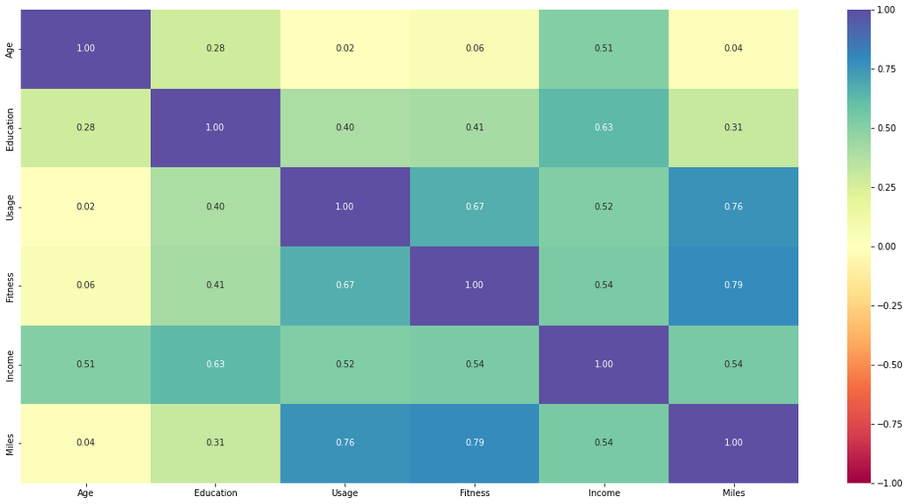

```python
# build an array of the numberic columns
num_cols = ['Age', 'Education', 'Usage', 'Fitness', 'Income', 'Miles']

corr = df[num_cols].corr()

# plot a heatmap of the data in the numerical colums
plt.figure(figsize=(20,10))
sns.heatmap(corr, annot=True, vmin=-1, vmax=1, fmt=".2f", cmap="Spectral")
plt.show()
```

```python
corr
```

|  | Age | Education | Usage | Fitness | Income | Miles |
| --- | --- | --- | --- | --- | --- | --- |
| Age | 1.000000 | 0.280496 | 0.015064 | 0.061105 | 0.513414 | 0.036618 |
| Education | 0.280496 | 1.000000 | 0.395155 | 0.410581 | 0.625827 | 0.307284 |
| Usage | 0.015064 | 0.395155 | 1.000000 | 0.668606 | 0.519537 | 0.759130 |
| Fitness | 0.061105 | 0.410581 | 0.668606 | 1.000000 | 0.535005 | 0.785702 |
| Income | 0.513414 | 0.625827 | 0.519537 | 0.535005 | 1.000000 | 0.543473 |
| Miles | 0.036618 | 0.307284 | 0.759130 | 0.785702 | 0.543473 | 1.000000 |

- While it may not be suprising
  - Estimated Usage, Estimated Miles, and Self Reported Fitness Level are all highly correlated
  - Income is correlated with education
- Income is also correlated with Self Reported Fitness Level, Miles, Age, and Usage
- Age and Estimated Miles, Self Reported Fitness Level, Estimated Usage, and education are not correlated very much
- There are no negative correlations

### Scatter Plots

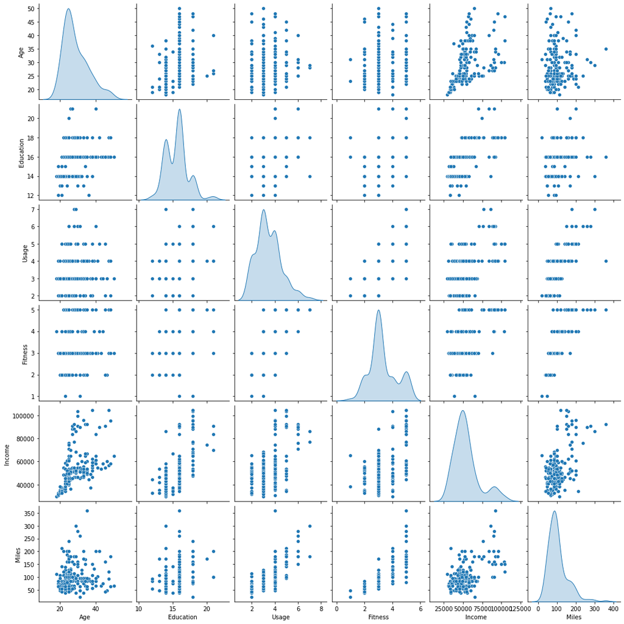

```python
sns.pairplot(data=df[num_cols], diag_kind="kde")
plt.show()
```

### Boxplot grapns for Product

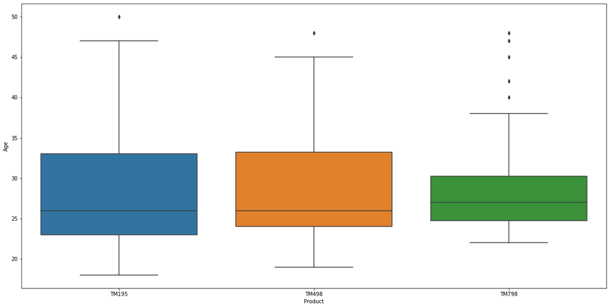

```python
# age by product box plot to see outliers the mean and the different quartiles

plt.figure(figsize=(20,10))
sns.boxplot(x=df['Product'], y=df['Age'])
plt.ylabel('Age')
plt.xlabel('Product')
plt.show()
```

- The younger you are the more likely you will purchase a TM195 but the oldest person in the data purchsed the TM195 (One outlier)
- The 1th and 3rd quartile of age are just slightly higher for the TM498 but the mean is the same when compated to the TM195
- The data shows that there are many outliers in terms of age for th TM798

```python
# education by product box plot to see outliers the mean and the different quartiles

plt.figure(figsize=(20,10))
sns.boxplot(x=df['Product'], y=df['Education'])
plt.ylabel('Education')
plt.xlabel('Product')
plt.show()
```

[output not shown]

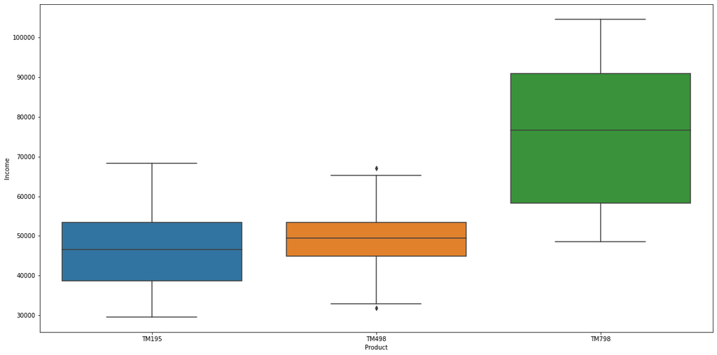

```python
# income by product box plot to see outliers the mean and the different quartiles

plt.figure(figsize=(20,10))
sns.boxplot(x=df['Product'], y=df['Income'])
plt.ylabel('Income')
plt.xlabel('Product')
plt.show()
```

- The higher your income the more likely that you will purchase the TM798
- The rage of income of customers who purchase the TM498 is relatively small when compared the the income levels that puchase the TM195 or the TM798

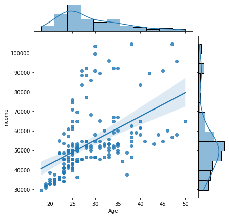

```python
# age and income joint plot
sns.jointplot(data=df, x="Age", y="Income", kind="reg")
plt.show();
```

- as shown in the heat map and as could likely be assumed, as age increaes so does income

# Multivariate Analysis

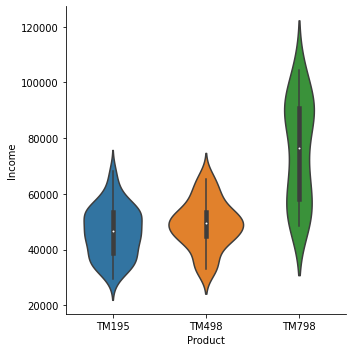

```python
# Dispersion of Income for each product
plt.figure(figsize=(20,10))
sns.catplot(data=df, x='Product', y='Income', kind="violin")
plt.show()
```

```python
df.groupby(by = ['Product', 'Gender'])['Income'].mean()
```

```
Product  Gender
TM195    Female    46020.075000
         Male      46815.975000
TM498    Female    49336.448276
         Male      48634.258065
TM798    Female    73633.857143
         Male      75825.030303
Name: Income, dtype: float64
```

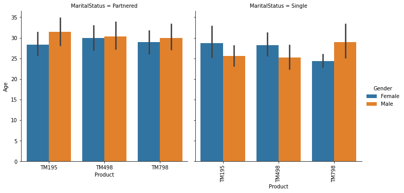

```python
# Prodct & Age, with Gender hue and compaing MaritalStatus

sns.catplot(data=df, x="Product", y="Age", hue="Gender", col="MaritalStatus", kind="bar")
plt.xticks(rotation=90)
plt.show()
```

- Married Male Customers average age is around 29 or 30 for each product
- Married Female Customers aveage age is 28 for the TM195, 30 for the TM498, and 29 for the TM798
- More Single women but the TM195 and TM498 than single men
- The average age for women who buy the TM195 and TM 498 is 29
- The average age for women who buy the TM798 is 24
- The average age for men who buy treadmills is lower than the aerage age of married men who by treadmills
- The TM798 is purchased by single men and the average age of those men is 30

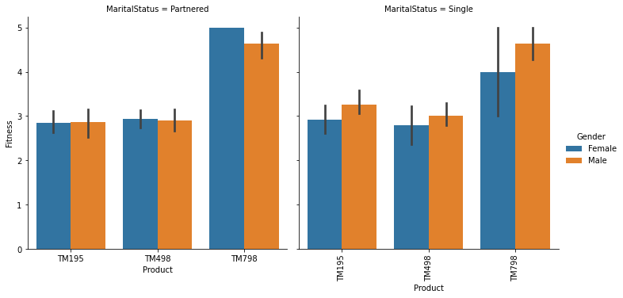

```python
# Prodct & Fitness, with Gender hue and compaing MaritalStaus
sns.catplot(data=df, x="Product", y="Fitness", hue="Gender", col="MaritalStatus", kind="bar")
plt.xticks(rotation=90)
plt.show()
```

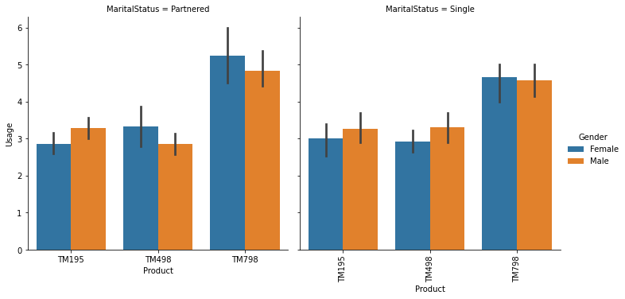

```python
# Prodct & usage, with Gender hue and compaing MaritalStatus

sns.catplot(data=df, x="Product", y="Usage", hue="Gender", col="MaritalStatus", kind="bar")
plt.xticks(rotation=90)
plt.show()
```

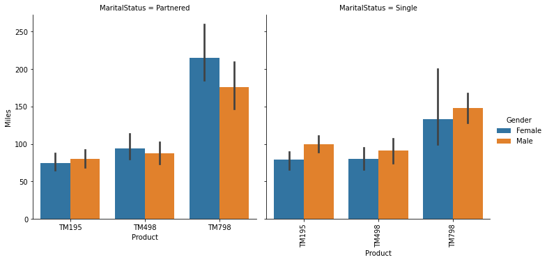

```python
# Prodct & Miles, with Gender hue and compaing MaritalStatus

sns.catplot(data=df, x="Product", y="Miles", hue="Gender", col="MaritalStatus", kind="bar")
plt.xticks(rotation=90)
plt.show()
```

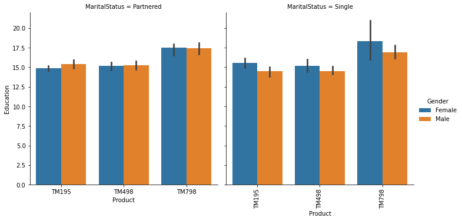

```python
# Prodct & Education, with Gender hue and compaing MaritalStatus

sns.catplot(data=df, x="Product", y="Education", hue="Gender", col="MaritalStatus", kind="bar")
plt.xticks(rotation=90)
plt.show()
```

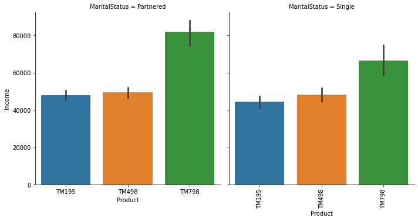

```python
# Prodct & Income, compaing MaritalStatus

sns.catplot(data=df, x="Product", y="Income", col="MaritalStatus", kind="bar")
plt.xticks(rotation=90)
plt.show()
```

This section is not part of the offial analysis but is for exporting the fully run notebook as HTML

```python
%%shell
jupyter nbconvert --to html "/content/drive/MyDrive/Colab Notebooks/01 - Fundamentals of AIML/Project/Fundamentals_of_AIML_Project.ipynb"
```

```
[NbConvertApp] Converting notebook /content/drive/MyDrive/Colab Notebooks/01 - Fundamentals of AIML/Project/Fundamentals_of_AIML_Project.ipynb to html
[NbConvertApp] Writing 320528 bytes to /content/drive/MyDrive/Colab Notebooks/01 - Fundamentals of AIML/Project/Fundamentals_of_AIML_Project.html
```